# Abschlussprojekt

rstatsZH-K009:

Author

DaaniiH

# Packages laden

```r
library(readr)
library(dplyr)
library(ggplot2)
library(tidyverse)
library(forcats)
library(ggthemes)
library(scales)
library(lubridate)
library(knitr)     # Package wird für Funktion kable() geladen
library(DT)        # Package wird für Funktion datatable() geladen
library(gt)        # Package wird für Funktion gt() geladen
library(kableExtra) # Package wird für detailiertere kable() bzw. kbl() Tabellen benötigt.
```

# Daten laden

```r
data_staatenkleingruppe <-  read_csv(here::here("data/raw/Quartiere_Jahr_KTZH_00002604_00005328.csv"))
data_auslaenderanteil_kantonal <- read_delim('https://www.web.statistik.zh.ch/ogd/data/KANTON_ZUERICH_205.csv')
```

```
──────────────────────────────────────────────────────── Delimiter: "," chr
(7): GEBIET_NAME, THEMA_NAME, SET_NAME, SUBSET_NAME, INDIKATOR_NAME, EIN... dbl
(4): BFS_NR, INDIKATOR_ID, INDIKATOR_JAHR, INDIKATOR_VALUE lgl (1): ...12
```

```r
# tbd
# data_geo_coordinates_ktzh <- read_csv
```

# Einleitung

Die Bevölkerung in Winterthur - Ein Einblick in die Entwicklung des Ausländeranteils.

## Daten

Bei den Rohdatenhandelt es sich um CSV Dateien aus dem Datenkatalog des Kantons Zürich.

Quellen

- Bevölkerung, nach Staatenkleingruppe und Quartier  
  https://www.zh.ch/de/politik-staat/statistik-daten/datenkatalog.html#/datasets/2604@stadt-winterthur
- Ausländeranteil  
  https://openzh.github.io/starter-code-openZH/  
  https://www.zh.ch/de/politik-staat/statistik-daten/datenkatalog.html#/datasets/68@statistisches-amt-kanton-zuerich
- Link zum GIS Browser Datendownload  
  https://www.zh.ch/de/politik-staat/statistik-daten/datenkatalog.html#/datasets/278@opendata-giszh-ktzh/distributions/1 bzw. http://maps.zh.ch/?topic=BASISKARTEZH&showtab=ogddownload

## Analyseziele

Im Rahmen der Analyse werden die Daten aufbereitet und in ein Tidy Data Format gebracht, erkundet und visualisiert.

- **Teil 1**  
  Erkenntnisse zur Entwicklung von **Ausländeranteil** der Stadt Winterthur (sowie der Stadkreise bzw. Quartiere) über die vergangenen 10 Jahre schaffen.

  Benötigte Daten: Jahr, Ausländeranteil, Gebiet (inkl. Koordinaten)

# Daten Aufbereitung

Erster Teil der Analyse, Entwicklung des Ausländeranteils der vergangenen 10 Jahre.

### Staatenkleingruppen

#### Vorwort zur Problemstellung mit “Viewern”

> 1. Die Funktion **`view()`** kann nicht in ein Quarto Dokument eingebettet werden und muss deshalb bei Erstellung desselben ausgeschlossen werden.
> 2. Die **viewer `gt()`** und **`kable()`** produzieren u.U. komplexe/grosse Tabellen, dies kann zu **Rendering-Problemen** bei der Gerneration von Quarto-Dokumenten führen.

>    Nachfolgend werden grosse Tabellen dargestellt, welche vermutlich aufgrund Memory Exhaustion einen Seitenrefresh triggern und dadurch die Generierung des Quarto Dokuments abgebrochen.

#### Daten betrachten

```r
# Komplettes dataframe als interaktive Tabelle
datatable(data_staatenkleingruppe, height = 500)
```

|  | jahr | gemeinde_bfs_nr | gemeinde | stadtkreis_bfs_nr | stadtkreis | quartier_bfs_nr | quartier | staatenkleingruppe | region | anzahl | anzahl_ist_kleingruppe |
| --- | --- | --- | --- | --- | --- | --- | --- | --- | --- | --- | --- |
| 1 | 2023 | 230 | Winterthur | 1 | Stadt | 110 | Altstadt | Afrika | übrige Kontinente |  | True |
| 2 | 2023 | 230 | Winterthur | 1 | Stadt | 110 | Altstadt | Amerika | übrige Kontinente | 22 | False |
| 3 | 2023 | 230 | Winterthur | 1 | Stadt | 110 | Altstadt | Asien | übrige Kontinente | 29 | False |
| 4 | 2023 | 230 | Winterthur | 1 | Stadt | 110 | Altstadt | Australien und Ozeanien | übrige Kontinente |  | True |
| 5 | 2023 | 230 | Winterthur | 1 | Stadt | 110 | Altstadt | Deutschland | Nord-, Mittel- und Westeuropa | 130 | False |
| 6 | 2023 | 230 | Winterthur | 1 | Stadt | 110 | Altstadt | Italien | Südeuropa | 47 | False |
| 7 | 2023 | 230 | Winterthur | 1 | Stadt | 110 | Altstadt | Kosovo | Südosteuropa |  | True |
| 8 | 2023 | 230 | Winterthur | 1 | Stadt | 110 | Altstadt | Mazedonien | Südosteuropa |  | True |
| 9 | 2023 | 230 | Winterthur | 1 | Stadt | 110 | Altstadt | Nordeuropa | Nord-, Mittel- und Westeuropa |  | True |
| 10 | 2023 | 230 | Winterthur | 1 | Stadt | 110 | Altstadt | Österreich | Nord-, Mittel- und Westeuropa | 22 | False |

[output cut: 7296 more lines]

```r
# Ein flüchtiger Blick ("glimpse") auf die Daten
glimpse(data_staatenkleingruppe)
```

```
Rows: 7,306
Columns: 11
$ jahr                   <dbl> 2023, 2023, 2023, 2023, 2023, 2023, 2023, 2023,…
$ gemeinde_bfs_nr        <dbl> 230, 230, 230, 230, 230, 230, 230, 230, 230, 23…
$ gemeinde               <chr> "Winterthur", "Winterthur", "Winterthur", "Wint…
$ stadtkreis_bfs_nr      <dbl> 1, 1, 1, 1, 1, 1, 1, 1, 1, 1, 1, 1, 1, 1, 1, 1,…
$ stadtkreis             <chr> "Stadt", "Stadt", "Stadt", "Stadt", "Stadt", "S…
$ quartier_bfs_nr        <dbl> 110, 110, 110, 110, 110, 110, 110, 110, 110, 11…
$ quartier               <chr> "Altstadt", "Altstadt", "Altstadt", "Altstadt",…
$ staatenkleingruppe     <chr> "Afrika", "Amerika", "Asien", "Australien und O…
$ region                 <chr> "übrige Kontinente", "übrige Kontinente", "übri…
$ anzahl                 <dbl> NA, 22, 29, NA, 130, 47, NA, NA, NA, 22, 23, NA…
$ anzahl_ist_kleingruppe <lgl> TRUE, FALSE, FALSE, TRUE, FALSE, FALSE, TRUE, T…
```

```r
# Spaltenüberschriften des df
names(data_staatenkleingruppe)
```

```
 [1] "jahr"                   "gemeinde_bfs_nr"        "gemeinde"
 [4] "stadtkreis_bfs_nr"      "stadtkreis"             "quartier_bfs_nr"
 [7] "quartier"               "staatenkleingruppe"     "region"
[10] "anzahl"                 "anzahl_ist_kleingruppe"
```

```r
# Einzigartige Werte der Spalten von Interesse - Staatenkleingruppen
unique(data_staatenkleingruppe$staatenkleingruppe)
```

```
 [1] "Afrika"                  "Amerika"
 [3] "Asien"                   "Australien und Ozeanien"
 [5] "Deutschland"             "Italien"
 [7] "Kosovo"                  "Mazedonien"
 [9] "Nordeuropa"              "Österreich"
[11] "Osteuropa und Russland"  "Portugal"
[13] "Schweiz"                 "Serbien"
[15] "Spanien"                 "Türkei"
[17] "übriges Mitteleuropa"    "übriges Südosteuropa"
[19] "Westeuropa"              "Bosnien u. Herzegowina"
[21] "unbekannt"
```

```r
# Einzigartige Werte der Spalten von Interesse - Stadtkreise
unique(data_staatenkleingruppe$stadtkreis)
```

```
[1] "Stadt"          "Veltheim"       "Seen"           "Töss"
[5] "Mattenbach"     "Oberwinterthur" "Wülflingen"     "unbekannt"
```

```r
# Einzigartige Werte der Spalten von Interesse - Quartiere
unique(data_staatenkleingruppe$quartier)
```

```
 [1] "Altstadt"    "Blumenau"    "Brühlberg"   "Büelwiesen"  "Dättnau"
 [6] "Deutweg"     "Eichliacker" "Eidberg"     "Endliker"    "Ganzenbühl"
[11] "Gotzenwil"   "Grüze"       "Guggenbühl"  "Gutschick"   "Hardau"
[16] "Härti"       "Hegi"        "Hegmatten"   "Heiligberg"  "Iberg"
[21] "Lind"        "Lindenplatz" "Neuburg"     "Neuwiesen"   "Niederfeld"
[26] "Oberfeld"    "Oberseen"    "Reutlingen"  "Ricketwil"   "Rosenberg"
[31] "Rossberg"    "Schlosstal"  "Sennhof"     "Sonnenberg"  "Stadel"
[36] "Taggenberg"  "Talacker"    "Tössfeld"    "Waldegg"     "Waser"
[41] "Weinberg"    "Zinzikon"    "unbekannt"
```

```r
# Einwohner pro Jahr - Dient u.a. zur Einschätzung der Grössenordnung
data_staatenkleingruppe %>%
  group_by(jahr) %>%
  summarize(summe_anzahl = sum(anzahl, na.rm = TRUE))
```

```
# A tibble: 10 × 2
    jahr summe_anzahl
   <dbl>        <dbl>
 1  2014       106415
 2  2015       108007
 3  2016       109632
 4  2017       110585
 5  2018       111651
 6  2019       113006
 7  2020       113969
 8  2021       114971
 9  2022       118134
10  2023       119419
```

#### NA prüfen / ausschliessen

```r
## NA-Ausschluss für Spalte "anzahl" kann mit Filter auf "anzahl_ist_kleingruppe" gemacht werden.

## Übersicht
data_staatenkleingruppe %>%
  group_by(anzahl_ist_kleingruppe, jahr) %>%
  summarise(anzahl_zeilen = n(),
            summe_anzahl = sum(anzahl, na.rm = TRUE))
```

```
# A tibble: 20 × 4
# Groups:   anzahl_ist_kleingruppe [2]
   anzahl_ist_kleingruppe  jahr anzahl_zeilen summe_anzahl
   <lgl>                  <dbl>         <int>        <dbl>
 1 FALSE                   2014           398       106415
 2 FALSE                   2015           405       108007
 3 FALSE                   2016           415       109632
 4 FALSE                   2017           411       110585
 5 FALSE                   2018           418       111651
 6 FALSE                   2019           421       113006
 7 FALSE                   2020           424       113969
 8 FALSE                   2021           429       114971
 9 FALSE                   2022           463       118134
10 FALSE                   2023           463       119419
11 TRUE                    2014           321            0
12 TRUE                    2015           317            0
13 TRUE                    2016           312            0
14 TRUE                    2017           317            0
15 TRUE                    2018           313            0
16 TRUE                    2019           308            0
17 TRUE                    2020           308            0
18 TRUE                    2021           304            0
19 TRUE                    2022           278            0
20 TRUE                    2023           281            0
```

```r
## Auschluss NA-Zeilen
data_staatenkleingruppe_false <- data_staatenkleingruppe %>%
  filter(anzahl_ist_kleingruppe == FALSE)

datatable(data_staatenkleingruppe_false, height = 250)
```

|  | jahr | gemeinde_bfs_nr | gemeinde | stadtkreis_bfs_nr | stadtkreis | quartier_bfs_nr | quartier | staatenkleingruppe | region | anzahl | anzahl_ist_kleingruppe |
| --- | --- | --- | --- | --- | --- | --- | --- | --- | --- | --- | --- |
| 1 | 2023 | 230 | Winterthur | 1 | Stadt | 110 | Altstadt | Amerika | übrige Kontinente | 22 | False |
| 2 | 2023 | 230 | Winterthur | 1 | Stadt | 110 | Altstadt | Asien | übrige Kontinente | 29 | False |
| 3 | 2023 | 230 | Winterthur | 1 | Stadt | 110 | Altstadt | Deutschland | Nord-, Mittel- und Westeuropa | 130 | False |
| 4 | 2023 | 230 | Winterthur | 1 | Stadt | 110 | Altstadt | Italien | Südeuropa | 47 | False |
| 5 | 2023 | 230 | Winterthur | 1 | Stadt | 110 | Altstadt | Österreich | Nord-, Mittel- und Westeuropa | 22 | False |
| 6 | 2023 | 230 | Winterthur | 1 | Stadt | 110 | Altstadt | Osteuropa und Russland | Osteuropa | 23 | False |
| 7 | 2023 | 230 | Winterthur | 1 | Stadt | 110 | Altstadt | Schweiz | Nord-, Mittel- und Westeuropa | 1685 | False |
| 8 | 2023 | 230 | Winterthur | 1 | Stadt | 110 | Altstadt | übriges Mitteleuropa | Nord-, Mittel- und Westeuropa | 25 | False |
| 9 | 2023 | 230 | Winterthur | 1 | Stadt | 110 | Altstadt | Westeuropa | Nord-, Mittel- und Westeuropa | 47 | False |
| 10 | 2023 | 230 | Winterthur | 5 | Veltheim | 520 | Blumenau | Afrika | übrige Kontinente | 76 | False |

[output cut: 4237 more lines]

> Alternative Varianten, falls Filter auf NA-Werten nicht bereits existiert, sind u.a.
> - Filter auf Spalte “Anzahl  
>   `filter(is.na(anzahl)) bzw. filter(!is.na(anzahl))`
> - Filter auf Datensätze mit NA in irgendeiner resp. keiner Spalte  
>   `filter(if_any(everything(), is.na))`  
>   oder  
>   `data_staatenkleingruppe[complete.cases(data_staatenkleingruppe), ]` bzw.  
>   `data_staatenkleingruppe[!complete.cases(data_staatenkleingruppe), ]`

> ```
> Alternativer Code nachfolgend vorhanden aber nicht ausgegeben im Quarto Dokument.
> ```

#### Feld “**herkunft**” hinzufügen, dataframe reduzieren auf benötigte Felder und danach als CSV speichern

```r
data_staatenkleingruppe_reduced <- data_staatenkleingruppe_false %>%
  mutate(herkunft = case_when(staatenkleingruppe != "Schweiz" ~  "Ausland",
                              TRUE                            ~  "Schweiz")) %>%
  select(jahr, herkunft, stadtkreis, quartier, anzahl) %>%
  group_by(jahr, herkunft, stadtkreis, quartier) %>%
  summarise(anzahl = sum(anzahl),
            .groups = "drop")
```

> WICHTIG: **.groups** Argument wird benötigt. Das Ergebnis nach Verwendung von group_by() und summarise() **bleibt sonst standardmäßig gruppiert** und so ist die Anzeige via z.B. gt() suboptimal.

> Nachfolgend ist ein Code Chunk mit kable() und gt() aufgrund des Reender Problems ausgeschlossen (siehe Vorwort zur Problemstellung mit “Viewern”)

```r
datatable(data_staatenkleingruppe_false, height = "500px")
```

|  | jahr | gemeinde_bfs_nr | gemeinde | stadtkreis_bfs_nr | stadtkreis | quartier_bfs_nr | quartier | staatenkleingruppe | region | anzahl | anzahl_ist_kleingruppe |
| --- | --- | --- | --- | --- | --- | --- | --- | --- | --- | --- | --- |
| 1 | 2023 | 230 | Winterthur | 1 | Stadt | 110 | Altstadt | Amerika | übrige Kontinente | 22 | False |
| 2 | 2023 | 230 | Winterthur | 1 | Stadt | 110 | Altstadt | Asien | übrige Kontinente | 29 | False |
| 3 | 2023 | 230 | Winterthur | 1 | Stadt | 110 | Altstadt | Deutschland | Nord-, Mittel- und Westeuropa | 130 | False |
| 4 | 2023 | 230 | Winterthur | 1 | Stadt | 110 | Altstadt | Italien | Südeuropa | 47 | False |
| 5 | 2023 | 230 | Winterthur | 1 | Stadt | 110 | Altstadt | Österreich | Nord-, Mittel- und Westeuropa | 22 | False |
| 6 | 2023 | 230 | Winterthur | 1 | Stadt | 110 | Altstadt | Osteuropa und Russland | Osteuropa | 23 | False |
| 7 | 2023 | 230 | Winterthur | 1 | Stadt | 110 | Altstadt | Schweiz | Nord-, Mittel- und Westeuropa | 1685 | False |
| 8 | 2023 | 230 | Winterthur | 1 | Stadt | 110 | Altstadt | übriges Mitteleuropa | Nord-, Mittel- und Westeuropa | 25 | False |
| 9 | 2023 | 230 | Winterthur | 1 | Stadt | 110 | Altstadt | Westeuropa | Nord-, Mittel- und Westeuropa | 47 | False |
| 10 | 2023 | 230 | Winterthur | 5 | Veltheim | 520 | Blumenau | Afrika | übrige Kontinente | 76 | False |

[output cut: 4237 more lines]

```r
write_csv(x = data_staatenkleingruppe_reduced,
          here::here("data/processed/data_staatenkleingruppe_reduced.csv"))
```

#### Statistische Kennzahlen und Übersichten erstellen

Ausländeranteil der Stadt Winterthur der letzten 10 Jahre Table 1

```r
# Berechne die Gesamteinwohnerzahl pro Jahr


## Einwohner pro Jahr inkl. Ausländeranteil
## STADT
overview_city <- data_staatenkleingruppe_reduced %>%
  group_by(jahr) %>%
  summarize(einwohner = sum(anzahl, na.rm = TRUE),
            einwohner_ausland = sum(anzahl[herkunft == "Ausland"], na.rm = TRUE),
            anteil_ausland = einwohner_ausland / einwohner * 100,
            einwohner_schweiz = sum(anzahl[herkunft != "Ausland"], na.rm = TRUE),
            anteil_schweiz = einwohner_schweiz / einwohner  * 100,
            ## Alternative für ungroup()
            #.groups = "drop"
            ) %>%
  ungroup() %>%
  select(jahr,
         einwohner, einwohner_schweiz, anteil_schweiz, einwohner_ausland, anteil_ausland)

gt(overview_city)
```

Table 1: Ausländeranteil Stadt Winterthur der letzten 10 Jahre

| jahr | einwohner | einwohner_schweiz | anteil_schweiz | einwohner_ausland | anteil_ausland |
| --- | --- | --- | --- | --- | --- |
| 2014 | 106415 | 83100 | 78.09049 | 23315 | 21.90951 |
| 2015 | 108007 | 84209 | 77.96624 | 23798 | 22.03376 |
| 2016 | 109632 | 85063 | 77.58957 | 24569 | 22.41043 |
| 2017 | 110585 | 85668 | 77.46801 | 24917 | 22.53199 |
| 2018 | 111651 | 86293 | 77.28816 | 25358 | 22.71184 |
| 2019 | 113006 | 87043 | 77.02511 | 25963 | 22.97489 |
| 2020 | 113969 | 87492 | 76.76824 | 26477 | 23.23176 |
| 2021 | 114971 | 87957 | 76.50364 | 27014 | 23.49636 |
| 2022 | 118134 | 88846 | 75.20781 | 29288 | 24.79219 |
| 2023 | 119419 | 89316 | 74.79212 | 30103 | 25.20788 |

Ausländeranteil der Stadtkreise von Winterthur der letzten 10 Jahre Table 2

```r
## STADTKREIS
overview_stadtkreis <- data_staatenkleingruppe_reduced %>%
  group_by(jahr, stadtkreis) %>%
  summarize(einw_sk = sum(anzahl, na.rm = TRUE),
            einw_sk_ausland = sum(anzahl[herkunft == "Ausland"], na.rm = TRUE),
            anteil_sk_ausland = einw_sk_ausland / einw_sk * 100,
            einw_sk_schweiz = sum(anzahl[herkunft != "Ausland"], na.rm = TRUE),
            anteil_sk_schweiz = einw_sk_schweiz / einw_sk  * 100,
            ## Alternative für ungroup()
            #.groups = "drop"
            ) %>%
  ungroup() %>%
  left_join(overview_city, by = "jahr") %>%
  mutate(anteil_ausland_stadtkreis_gesamt = (einw_sk_ausland / einwohner) * 100) %>%
  select(jahr,
         stadtkreis,
         einw_sk,
         einw_sk_schweiz,
         anteil_sk_schweiz,
         einw_sk_ausland,
         anteil_sk_ausland,
         einwohner,
         anteil_ausland_stadtkreis_gesamt)
gt(overview_stadtkreis)
```

Table 2: Ausländeranteil der Stadtkreise von Winterthur der letzten 10 Jahre

| jahr | stadtkreis | einw_sk | einw_sk_schweiz | anteil_sk_schweiz | einw_sk_ausland | anteil_sk_ausland | einwohner | anteil_ausland_stadtkreis_gesamt |
| --- | --- | --- | --- | --- | --- | --- | --- | --- |
| 2014 | Mattenbach | 11958 | 9134 | 76.38401 | 2824 | 23.61599 | 106415 | 2.653761218 |
| 2014 | Oberwinterthur | 21918 | 16659 | 76.00602 | 5259 | 23.99398 | 106415 | 4.941972466 |
| 2014 | Seen | 17794 | 14869 | 83.56187 | 2925 | 16.43813 | 106415 | 2.748672650 |
| 2014 | Stadt | 19766 | 16013 | 81.01285 | 3753 | 18.98715 | 106415 | 3.526758446 |
| 2014 | Töss | 10306 | 7085 | 68.74636 | 3221 | 31.25364 | 106415 | 3.026828924 |
| 2014 | Veltheim | 9770 | 7914 | 81.00307 | 1856 | 18.99693 | 106415 | 1.744115021 |
| 2014 | Wülflingen | 14880 | 11417 | 76.72715 | 3463 | 23.27285 | 106415 | 3.254240474 |
| 2014 | unbekannt | 23 | 9 | 39.13043 | 14 | 60.86957 | 106415 | 0.013156040 |
| 2015 | Mattenbach | 12113 | 9271 | 76.53760 | 2842 | 23.46240 | 108007 | 2.631310934 |
| 2015 | Oberwinterthur | 22220 | 16809 | 75.64806 | 5411 | 24.35194 | 108007 | 5.009860472 |
| 2015 | Seen | 18129 | 15085 | 83.20922 | 3044 | 16.79078 | 108007 | 2.818335849 |
| 2015 | Stadt | 19806 | 16106 | 81.31879 | 3700 | 18.68121 | 108007 | 3.425703890 |
| 2015 | Töss | 10481 | 7290 | 69.55443 | 3191 | 30.44557 | 108007 | 2.954438138 |
| 2015 | Veltheim | 9876 | 7949 | 80.48805 | 1927 | 19.51195 | 108007 | 1.784143620 |
| 2015 | Wülflingen | 15367 | 11690 | 76.07210 | 3677 | 23.92790 | 108007 | 3.404408973 |
| 2015 | unbekannt | 15 | 9 | 60.00000 | 6 | 40.00000 | 108007 | 0.005555195 |
| 2016 | Mattenbach | 12184 | 9183 | 75.36934 | 3001 | 24.63066 | 109632 | 2.737339463 |
| 2016 | Oberwinterthur | 22603 | 16991 | 75.17144 | 5612 | 24.82856 | 109632 | 5.118943374 |
| 2016 | Seen | 18269 | 15159 | 82.97663 | 3110 | 17.02337 | 109632 | 2.836762989 |
| 2016 | Stadt | 20337 | 16450 | 80.88705 | 3887 | 19.11295 | 109632 | 3.545497665 |
| 2016 | Töss | 10541 | 7379 | 70.00285 | 3162 | 29.99715 | 109632 | 2.884194396 |
| 2016 | Veltheim | 9922 | 7964 | 80.26608 | 1958 | 19.73392 | 109632 | 1.785974898 |
| 2016 | Wülflingen | 15767 | 11934 | 75.68973 | 3833 | 24.31027 | 109632 | 3.496241973 |
| 2016 | unbekannt | 9 | 3 | 33.33333 | 6 | 66.66667 | 109632 | 0.005472855 |
| 2017 | Mattenbach | 12059 | 9029 | 74.87354 | 3030 | 25.12646 | 110585 | 2.739973776 |
| 2017 | Oberwinterthur | 22806 | 17161 | 75.24774 | 5645 | 24.75226 | 110585 | 5.104670615 |
| 2017 | Seen | 18372 | 15193 | 82.69649 | 3179 | 17.30351 | 110585 | 2.874711760 |
| 2017 | Stadt | 20567 | 16623 | 80.82365 | 3944 | 19.17635 | 110585 | 3.566487317 |
| 2017 | Töss | 10728 | 7535 | 70.23676 | 3193 | 29.76324 | 110585 | 2.887371705 |
| 2017 | Veltheim | 9988 | 8029 | 80.38646 | 1959 | 19.61354 | 110585 | 1.771487996 |
| 2017 | Wülflingen | 16065 | 12098 | 75.30657 | 3967 | 24.69343 | 110585 | 3.587285798 |
| 2018 | Mattenbach | 12081 | 9052 | 74.92757 | 3029 | 25.07243 | 111651 | 2.712917932 |
| 2018 | Oberwinterthur | 23230 | 17432 | 75.04090 | 5798 | 24.95910 | 111651 | 5.192967372 |
| 2018 | Seen | 18845 | 15500 | 82.24993 | 3345 | 17.75007 | 111651 | 2.995942714 |
| 2018 | Stadt | 20774 | 16855 | 81.13507 | 3919 | 18.86493 | 111651 | 3.510044693 |
| 2018 | Töss | 10812 | 7519 | 69.54310 | 3293 | 30.45690 | 111651 | 2.949369016 |
| 2018 | Veltheim | 9934 | 7934 | 79.86712 | 2000 | 20.13288 | 111651 | 1.791296092 |
| 2018 | Wülflingen | 15975 | 12001 | 75.12363 | 3974 | 24.87637 | 111651 | 3.559305335 |
| 2019 | Mattenbach | 12258 | 9175 | 74.84908 | 3083 | 25.15092 | 113006 | 2.728173725 |
| 2019 | Oberwinterthur | 23750 | 17643 | 74.28632 | 6107 | 25.71368 | 113006 | 5.404137833 |
| 2019 | Seen | 19328 | 15804 | 81.76738 | 3524 | 18.23262 | 113006 | 3.118418491 |
| 2019 | Stadt | 20843 | 16991 | 81.51898 | 3852 | 18.48102 | 113006 | 3.408668566 |
| 2019 | Töss | 10988 | 7568 | 68.87514 | 3420 | 31.12486 | 113006 | 3.026387979 |
| 2019 | Veltheim | 9894 | 7933 | 80.17991 | 1961 | 19.82009 | 113006 | 1.735306090 |
| 2019 | Wülflingen | 15945 | 11929 | 74.81342 | 4016 | 25.18658 | 113006 | 3.553793604 |
| 2020 | Mattenbach | 12264 | 9180 | 74.85323 | 3084 | 25.14677 | 113969 | 2.705999000 |
| 2020 | Oberwinterthur | 23937 | 17655 | 73.75611 | 6282 | 26.24389 | 113969 | 5.512025200 |
| 2020 | Seen | 19598 | 15867 | 80.96234 | 3731 | 19.03766 | 113969 | 3.273697233 |
| 2020 | Stadt | 21023 | 17272 | 82.15764 | 3751 | 17.84236 | 113969 | 3.291245865 |
| 2020 | Töss | 10995 | 7563 | 68.78581 | 3432 | 31.21419 | 113969 | 3.011345190 |
| 2020 | Veltheim | 10050 | 7995 | 79.55224 | 2055 | 20.44776 | 113969 | 1.803121902 |
| 2020 | Wülflingen | 16102 | 11960 | 74.27649 | 4142 | 25.72351 | 113969 | 3.634321614 |
| 2021 | Mattenbach | 12257 | 9082 | 74.09643 | 3175 | 25.90357 | 114971 | 2.761565960 |
| 2021 | Oberwinterthur | 24082 | 17823 | 74.00963 | 6259 | 25.99037 | 114971 | 5.443981526 |
| 2021 | Seen | 19684 | 15885 | 80.70006 | 3799 | 19.29994 | 114971 | 3.304311522 |
| 2021 | Stadt | 21495 | 17514 | 81.47941 | 3981 | 18.52059 | 114971 | 3.462612311 |
| 2021 | Töss | 11108 | 7651 | 68.87829 | 3457 | 31.12171 | 114971 | 3.006845204 |
| 2021 | Veltheim | 10007 | 7955 | 79.49435 | 2052 | 20.50565 | 114971 | 1.784797906 |
| 2021 | Wülflingen | 16338 | 12047 | 73.73608 | 4291 | 26.26392 | 114971 | 3.732245523 |
| 2022 | Mattenbach | 12631 | 8999 | 71.24535 | 3632 | 28.75465 | 118134 | 3.074474749 |
| 2022 | Oberwinterthur | 25171 | 18370 | 72.98081 | 6801 | 27.01919 | 118134 | 5.757021687 |
| 2022 | Seen | 20181 | 16080 | 79.67891 | 4101 | 20.32109 | 118134 | 3.471481538 |
| 2022 | Stadt | 22180 | 17686 | 79.73850 | 4494 | 20.26150 | 118134 | 3.804154604 |
| 2022 | Töss | 11298 | 7744 | 68.54310 | 3554 | 31.45690 | 118134 | 3.008448034 |
| 2022 | Veltheim | 10108 | 7961 | 78.75940 | 2147 | 21.24060 | 118134 | 1.817427667 |
| 2022 | Wülflingen | 16565 | 12006 | 72.47812 | 4559 | 27.52188 | 118134 | 3.859176867 |
| 2023 | Mattenbach | 12613 | 8911 | 70.64933 | 3702 | 29.35067 | 119419 | 3.100009211 |
| 2023 | Oberwinterthur | 25390 | 18491 | 72.82788 | 6899 | 27.17212 | 119419 | 5.777137641 |
| 2023 | Seen | 20293 | 16068 | 79.18001 | 4225 | 20.81999 | 119419 | 3.537962971 |
| 2023 | Stadt | 22690 | 17979 | 79.23755 | 4711 | 20.76245 | 119419 | 3.944933386 |
| 2023 | Töss | 11505 | 7773 | 67.56193 | 3732 | 32.43807 | 119419 | 3.125130842 |
| 2023 | Veltheim | 10237 | 8042 | 78.55817 | 2195 | 21.44183 | 119419 | 1.838065969 |
| 2023 | Wülflingen | 16691 | 12052 | 72.20658 | 4639 | 27.79342 | 119419 | 3.884641472 |

Ausländeranteil der Quartiere von Winterthur der letzten 10 Jahre Table 3

```r
## Quartier
overview_quartier <- data_staatenkleingruppe_reduced %>%
  group_by(jahr, stadtkreis, quartier) %>%
  summarize(einwohner = sum(anzahl, na.rm = TRUE),
            einwohner_ausland = sum(anzahl[herkunft == "Ausland"], na.rm = TRUE),
            anteil_ausland = einwohner_ausland / einwohner * 100,
            einwohner_schweiz = sum(anzahl[herkunft != "Ausland"], na.rm = TRUE),
            anteil_schweiz = einwohner_schweiz / einwohner  * 100,
            ## Alternative für ungroup()
            #.groups = "drop"
            ) %>%
  ungroup() %>%
  select(jahr, stadtkreis, quartier,
         einwohner, einwohner_schweiz, anteil_schweiz, einwohner_ausland, anteil_ausland)
gt(overview_quartier)
############################################################################
# tbd
#
#
# #Alter ist nicht in data_statenkleingruppe. Es wird deshalb geprüft ob diese Angabe aus einer anderen Quelle hinzugenommen werden kann.
#
# names(data_geschlecht_heimat)
# nrow(data_geschlecht_heimat)
# glimpse(data_geschlecht_heimat)
#
#
#
# Nationalität (CH/non-CH)
#
# optional: Geschlecht
```

Table 3: Ausländeranteil der Quartiere von Winterthur der letzten 10 Jahre

| jahr | stadtkreis | quartier | einwohner | einwohner_schweiz | anteil_schweiz | einwohner_ausland | anteil_ausland |
| --- | --- | --- | --- | --- | --- | --- | --- |
| 2014 | Mattenbach | Deutweg | 6772 | 5403 | 79.78441 | 1369 | 20.215594 |
| 2014 | Mattenbach | Endliker | 2116 | 1610 | 76.08696 | 506 | 23.913043 |
| 2014 | Mattenbach | Gutschick | 3070 | 2121 | 69.08795 | 949 | 30.912052 |
| 2014 | Oberwinterthur | Grüze | 1665 | 1298 | 77.95796 | 367 | 22.042042 |
| 2014 | Oberwinterthur | Guggenbühl | 5589 | 3884 | 69.49365 | 1705 | 30.506352 |
| 2014 | Oberwinterthur | Hegi | 3339 | 2513 | 75.26205 | 826 | 24.737945 |
| 2014 | Oberwinterthur | Hegmatten | 1771 | 1380 | 77.92208 | 391 | 22.077922 |
| 2014 | Oberwinterthur | Reutlingen | 343 | 343 | 100.00000 | 0 | 0.000000 |
| 2014 | Oberwinterthur | Ricketwil | 83 | 83 | 100.00000 | 0 | 0.000000 |
| 2014 | Oberwinterthur | Stadel | 263 | 263 | 100.00000 | 0 | 0.000000 |
| 2014 | Oberwinterthur | Talacker | 6207 | 4781 | 77.02594 | 1426 | 22.974062 |
| 2014 | Oberwinterthur | Zinzikon | 2658 | 2114 | 79.53348 | 544 | 20.466516 |
| 2014 | Seen | Büelwiesen | 2890 | 2178 | 75.36332 | 712 | 24.636678 |
| 2014 | Seen | Eidberg | 167 | 167 | 100.00000 | 0 | 0.000000 |
| 2014 | Seen | Ganzenbühl | 2799 | 2280 | 81.45766 | 519 | 18.542337 |
| 2014 | Seen | Gotzenwil | 615 | 615 | 100.00000 | 0 | 0.000000 |
| 2014 | Seen | Iberg | 1020 | 949 | 93.03922 | 71 | 6.960784 |
| 2014 | Seen | Oberseen | 2324 | 2120 | 91.22203 | 204 | 8.777969 |
| 2014 | Seen | Sennhof | 1140 | 822 | 72.10526 | 318 | 27.894737 |
| 2014 | Seen | Sonnenberg | 882 | 849 | 96.25850 | 33 | 3.741497 |
| 2014 | Seen | Waldegg | 1118 | 1059 | 94.72272 | 59 | 5.277281 |
| 2014 | Seen | Waser | 4839 | 3830 | 79.14858 | 1009 | 20.851416 |
| 2014 | Stadt | Altstadt | 2211 | 1871 | 84.62234 | 340 | 15.377657 |
| 2014 | Stadt | Brühlberg | 1772 | 1446 | 81.60271 | 326 | 18.397291 |
| 2014 | Stadt | Heiligberg | 3470 | 3024 | 87.14697 | 446 | 12.853026 |
| 2014 | Stadt | Lind | 5468 | 4579 | 83.74177 | 889 | 16.258230 |
| 2014 | Stadt | Neuwiesen | 3765 | 2917 | 77.47676 | 848 | 22.523240 |
| 2014 | Stadt | Tössfeld | 3080 | 2176 | 70.64935 | 904 | 29.350649 |
| 2014 | Töss | Dättnau | 3154 | 2363 | 74.92074 | 791 | 25.079264 |
| 2014 | Töss | Eichliacker | 3940 | 2509 | 63.68020 | 1431 | 36.319797 |

[output cut: 387 more lines]

# Daten Visualisierung

```r
# Die Visualisierung auf Ebene Stadtkreis zeigt einen Ausreisser namens "unbekannt". Es handelt sich um 3 Positionen aus den Jahren 2014, 2015 und 2016 welche knapp 50 Einwohne betreffen. Es handelt sich um eine vernachlässigbare Grössenordnung und wird in dieser Betrachtung deshalb ausgeschlossen.

overview_stadtkreis_unbekannt <- overview_stadtkreis %>%
  filter(stadtkreis == "unbekannt")

gt(overview_stadtkreis_unbekannt)
```

| jahr | stadtkreis | einw_sk | einw_sk_schweiz | anteil_sk_schweiz | einw_sk_ausland | anteil_sk_ausland | einwohner | anteil_ausland_stadtkreis_gesamt |
| --- | --- | --- | --- | --- | --- | --- | --- | --- |
| 2014 | unbekannt | 23 | 9 | 39.13043 | 14 | 60.86957 | 106415 | 0.013156040 |
| 2015 | unbekannt | 15 | 9 | 60.00000 | 6 | 40.00000 | 108007 | 0.005555195 |
| 2016 | unbekannt | 9 | 3 | 33.33333 | 6 | 66.66667 | 109632 | 0.005472855 |

```r
overview_stadtkreis_cleaned <- overview_stadtkreis %>%
  filter(stadtkreis != "unbekannt")

gt(overview_stadtkreis_cleaned)
```

| jahr | stadtkreis | einw_sk | einw_sk_schweiz | anteil_sk_schweiz | einw_sk_ausland | anteil_sk_ausland | einwohner | anteil_ausland_stadtkreis_gesamt |
| --- | --- | --- | --- | --- | --- | --- | --- | --- |
| 2014 | Mattenbach | 11958 | 9134 | 76.38401 | 2824 | 23.61599 | 106415 | 2.653761 |
| 2014 | Oberwinterthur | 21918 | 16659 | 76.00602 | 5259 | 23.99398 | 106415 | 4.941972 |
| 2014 | Seen | 17794 | 14869 | 83.56187 | 2925 | 16.43813 | 106415 | 2.748673 |
| 2014 | Stadt | 19766 | 16013 | 81.01285 | 3753 | 18.98715 | 106415 | 3.526758 |
| 2014 | Töss | 10306 | 7085 | 68.74636 | 3221 | 31.25364 | 106415 | 3.026829 |
| 2014 | Veltheim | 9770 | 7914 | 81.00307 | 1856 | 18.99693 | 106415 | 1.744115 |
| 2014 | Wülflingen | 14880 | 11417 | 76.72715 | 3463 | 23.27285 | 106415 | 3.254240 |
| 2015 | Mattenbach | 12113 | 9271 | 76.53760 | 2842 | 23.46240 | 108007 | 2.631311 |
| 2015 | Oberwinterthur | 22220 | 16809 | 75.64806 | 5411 | 24.35194 | 108007 | 5.009860 |
| 2015 | Seen | 18129 | 15085 | 83.20922 | 3044 | 16.79078 | 108007 | 2.818336 |
| 2015 | Stadt | 19806 | 16106 | 81.31879 | 3700 | 18.68121 | 108007 | 3.425704 |
| 2015 | Töss | 10481 | 7290 | 69.55443 | 3191 | 30.44557 | 108007 | 2.954438 |
| 2015 | Veltheim | 9876 | 7949 | 80.48805 | 1927 | 19.51195 | 108007 | 1.784144 |
| 2015 | Wülflingen | 15367 | 11690 | 76.07210 | 3677 | 23.92790 | 108007 | 3.404409 |
| 2016 | Mattenbach | 12184 | 9183 | 75.36934 | 3001 | 24.63066 | 109632 | 2.737339 |
| 2016 | Oberwinterthur | 22603 | 16991 | 75.17144 | 5612 | 24.82856 | 109632 | 5.118943 |
| 2016 | Seen | 18269 | 15159 | 82.97663 | 3110 | 17.02337 | 109632 | 2.836763 |
| 2016 | Stadt | 20337 | 16450 | 80.88705 | 3887 | 19.11295 | 109632 | 3.545498 |
| 2016 | Töss | 10541 | 7379 | 70.00285 | 3162 | 29.99715 | 109632 | 2.884194 |
| 2016 | Veltheim | 9922 | 7964 | 80.26608 | 1958 | 19.73392 | 109632 | 1.785975 |
| 2016 | Wülflingen | 15767 | 11934 | 75.68973 | 3833 | 24.31027 | 109632 | 3.496242 |
| 2017 | Mattenbach | 12059 | 9029 | 74.87354 | 3030 | 25.12646 | 110585 | 2.739974 |
| 2017 | Oberwinterthur | 22806 | 17161 | 75.24774 | 5645 | 24.75226 | 110585 | 5.104671 |
| 2017 | Seen | 18372 | 15193 | 82.69649 | 3179 | 17.30351 | 110585 | 2.874712 |
| 2017 | Stadt | 20567 | 16623 | 80.82365 | 3944 | 19.17635 | 110585 | 3.566487 |
| 2017 | Töss | 10728 | 7535 | 70.23676 | 3193 | 29.76324 | 110585 | 2.887372 |
| 2017 | Veltheim | 9988 | 8029 | 80.38646 | 1959 | 19.61354 | 110585 | 1.771488 |
| 2017 | Wülflingen | 16065 | 12098 | 75.30657 | 3967 | 24.69343 | 110585 | 3.587286 |
| 2018 | Mattenbach | 12081 | 9052 | 74.92757 | 3029 | 25.07243 | 111651 | 2.712918 |
| 2018 | Oberwinterthur | 23230 | 17432 | 75.04090 | 5798 | 24.95910 | 111651 | 5.192967 |
| 2018 | Seen | 18845 | 15500 | 82.24993 | 3345 | 17.75007 | 111651 | 2.995943 |
| 2018 | Stadt | 20774 | 16855 | 81.13507 | 3919 | 18.86493 | 111651 | 3.510045 |
| 2018 | Töss | 10812 | 7519 | 69.54310 | 3293 | 30.45690 | 111651 | 2.949369 |
| 2018 | Veltheim | 9934 | 7934 | 79.86712 | 2000 | 20.13288 | 111651 | 1.791296 |
| 2018 | Wülflingen | 15975 | 12001 | 75.12363 | 3974 | 24.87637 | 111651 | 3.559305 |
| 2019 | Mattenbach | 12258 | 9175 | 74.84908 | 3083 | 25.15092 | 113006 | 2.728174 |
| 2019 | Oberwinterthur | 23750 | 17643 | 74.28632 | 6107 | 25.71368 | 113006 | 5.404138 |
| 2019 | Seen | 19328 | 15804 | 81.76738 | 3524 | 18.23262 | 113006 | 3.118418 |
| 2019 | Stadt | 20843 | 16991 | 81.51898 | 3852 | 18.48102 | 113006 | 3.408669 |
| 2019 | Töss | 10988 | 7568 | 68.87514 | 3420 | 31.12486 | 113006 | 3.026388 |
| 2019 | Veltheim | 9894 | 7933 | 80.17991 | 1961 | 19.82009 | 113006 | 1.735306 |
| 2019 | Wülflingen | 15945 | 11929 | 74.81342 | 4016 | 25.18658 | 113006 | 3.553794 |
| 2020 | Mattenbach | 12264 | 9180 | 74.85323 | 3084 | 25.14677 | 113969 | 2.705999 |
| 2020 | Oberwinterthur | 23937 | 17655 | 73.75611 | 6282 | 26.24389 | 113969 | 5.512025 |
| 2020 | Seen | 19598 | 15867 | 80.96234 | 3731 | 19.03766 | 113969 | 3.273697 |
| 2020 | Stadt | 21023 | 17272 | 82.15764 | 3751 | 17.84236 | 113969 | 3.291246 |
| 2020 | Töss | 10995 | 7563 | 68.78581 | 3432 | 31.21419 | 113969 | 3.011345 |
| 2020 | Veltheim | 10050 | 7995 | 79.55224 | 2055 | 20.44776 | 113969 | 1.803122 |
| 2020 | Wülflingen | 16102 | 11960 | 74.27649 | 4142 | 25.72351 | 113969 | 3.634322 |
| 2021 | Mattenbach | 12257 | 9082 | 74.09643 | 3175 | 25.90357 | 114971 | 2.761566 |
| 2021 | Oberwinterthur | 24082 | 17823 | 74.00963 | 6259 | 25.99037 | 114971 | 5.443982 |
| 2021 | Seen | 19684 | 15885 | 80.70006 | 3799 | 19.29994 | 114971 | 3.304312 |
| 2021 | Stadt | 21495 | 17514 | 81.47941 | 3981 | 18.52059 | 114971 | 3.462612 |
| 2021 | Töss | 11108 | 7651 | 68.87829 | 3457 | 31.12171 | 114971 | 3.006845 |
| 2021 | Veltheim | 10007 | 7955 | 79.49435 | 2052 | 20.50565 | 114971 | 1.784798 |
| 2021 | Wülflingen | 16338 | 12047 | 73.73608 | 4291 | 26.26392 | 114971 | 3.732246 |
| 2022 | Mattenbach | 12631 | 8999 | 71.24535 | 3632 | 28.75465 | 118134 | 3.074475 |
| 2022 | Oberwinterthur | 25171 | 18370 | 72.98081 | 6801 | 27.01919 | 118134 | 5.757022 |
| 2022 | Seen | 20181 | 16080 | 79.67891 | 4101 | 20.32109 | 118134 | 3.471482 |
| 2022 | Stadt | 22180 | 17686 | 79.73850 | 4494 | 20.26150 | 118134 | 3.804155 |
| 2022 | Töss | 11298 | 7744 | 68.54310 | 3554 | 31.45690 | 118134 | 3.008448 |
| 2022 | Veltheim | 10108 | 7961 | 78.75940 | 2147 | 21.24060 | 118134 | 1.817428 |
| 2022 | Wülflingen | 16565 | 12006 | 72.47812 | 4559 | 27.52188 | 118134 | 3.859177 |
| 2023 | Mattenbach | 12613 | 8911 | 70.64933 | 3702 | 29.35067 | 119419 | 3.100009 |
| 2023 | Oberwinterthur | 25390 | 18491 | 72.82788 | 6899 | 27.17212 | 119419 | 5.777138 |
| 2023 | Seen | 20293 | 16068 | 79.18001 | 4225 | 20.81999 | 119419 | 3.537963 |
| 2023 | Stadt | 22690 | 17979 | 79.23755 | 4711 | 20.76245 | 119419 | 3.944933 |
| 2023 | Töss | 11505 | 7773 | 67.56193 | 3732 | 32.43807 | 119419 | 3.125131 |
| 2023 | Veltheim | 10237 | 8042 | 78.55817 | 2195 | 21.44183 | 119419 | 1.838066 |
| 2023 | Wülflingen | 16691 | 12052 | 72.20658 | 4639 | 27.79342 | 119419 | 3.884641 |

Stadt Winterthur und die Entwicklung des Ausländeranteils Figure 1

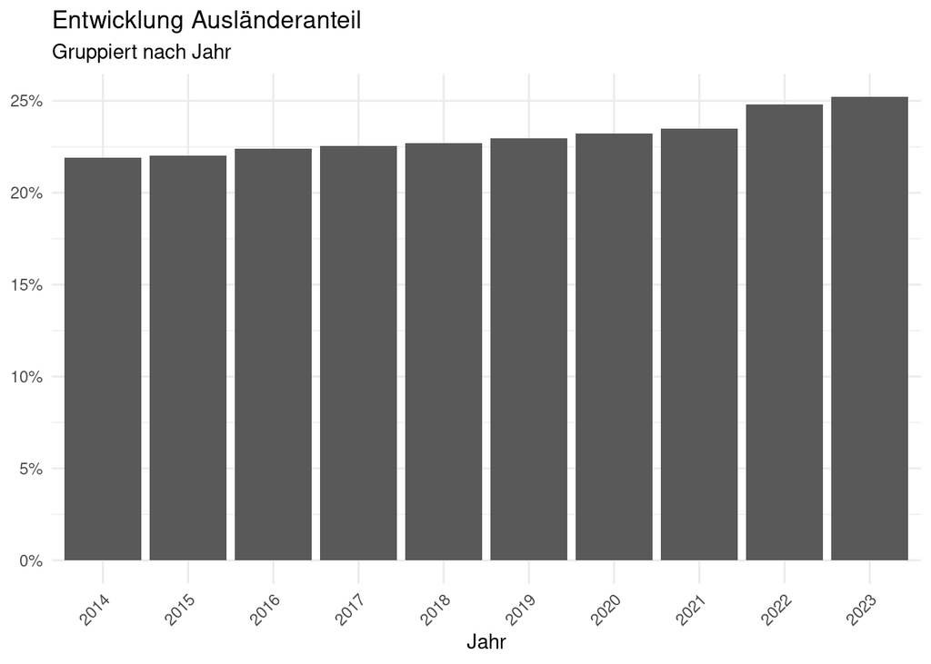

Figure 1: Entwicklung des prozentualen Ausländeranteils der Stadt Winterthur

```r
# Entwicklung Ausländeranteil
ggplot(data = overview_city,
       mapping = aes(x = factor(jahr),
                     y = anteil_ausland)) +
  geom_col(position = "stack") +

  theme_minimal() +
  theme(axis.text.x = element_text(angle = 45,
                                   hjust = 1)) +
  labs(x = "Jahr",
       y = NULL,
       title = "Entwicklung Ausländeranteil",
       subtitle = "Gruppiert nach Jahr") +
  scale_y_continuous(labels = scales::percent_format(scale = 1))
```

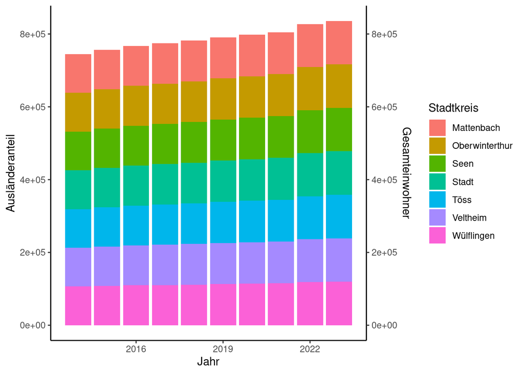

```r
ggplot(data = overview_stadtkreis_cleaned,
       mapping = aes(x = jahr,
                     y = einwohner,
                     fill = stadtkreis)) +
  geom_col(position = "stack") +
  geom_col(mapping = aes(x = jahr,
                         y = einwohner / 1000),
            fill = "lightblue",
            alpha = 0.5,
            position = "identity") +
  scale_y_continuous(name = "Ausländeranteil",
                     sec.axis = sec_axis(~ . * 1, name = "Gesamteinwohner")
  ) +
  labs(x = "Jahr", fill = "Stadtkreis") +
  theme_classic()
```

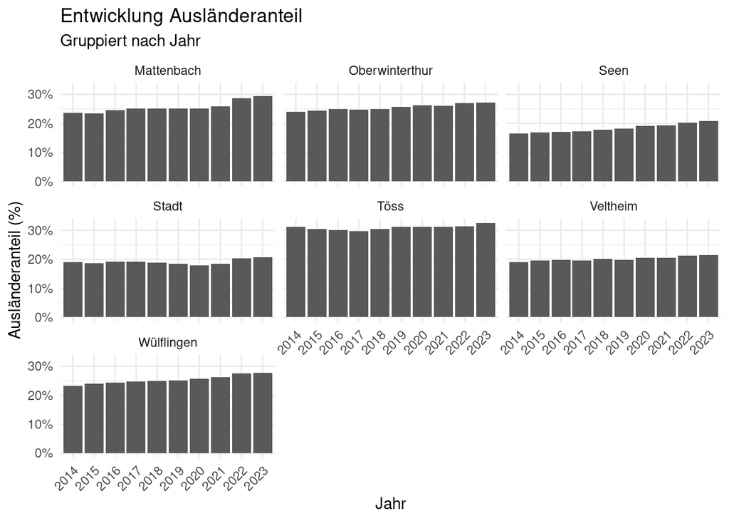

```r
#Entwicklung Ausländeranteil nach Stadtkreis
ggplot(data = overview_stadtkreis_cleaned,
       mapping = aes(x = factor(jahr),
                     y = anteil_sk_ausland)) +
  geom_col(position = "stack") +

  theme_minimal() +
  theme(axis.text.x = element_text(angle = 45,
                                   hjust = 1)) +
  labs(x = "Jahr",
       y = NULL,
       title = "Entwicklung Ausländeranteil",
       subtitle = "Gruppiert nach Jahr") +
  scale_y_continuous(labels = scales::percent_format(scale = 1)) +
  #Ein Graph pro Stadtkreis
  facet_wrap(~ stadtkreis) +
  labs(x = "Jahr", y = "Ausländeranteil (%)", color = "Stadtkreis")
```

WIP

[figure not shown]

```r
# Liniendiagramm mit Facetten
ggplot(data = overview_stadtkreis_cleaned,
       mapping = aes(x = jahr,
                     y = einwohner_ausland,
                     color = stadtkreis)) +


  geom_col(data = overview_stadtkreis_cleaned,
           mapping = aes(x = jahr,
                         y = einwohner),
           fill = "lightblue",
           alpha = 0.5,
           position = "identity") +
  scale_y_continuous(
    name = "Ausländeranteil (%)",
    sec.axis = sec_axis(~ . * 1, name = "Gesamteinwohner (Tausend)")
  ) +
  labs(x = "jahr") +
  theme_classic()
```